# Practical Machine Learning Final Project

Mahbubur Rashid

8/25/2019

```r
library(rattle)
library(caret)
```

```r
library(rpart)
library(rpart.plot)
library(corrplot)
library(randomForest)
library(RColorBrewer)
library(RCurl)
```

## Executive Summary

Personal wearable devices such as Jawbone Up, Nike FuelBand, and Fitbit provide an inexpensive way to collect a large amount of activity data of the respective users. The collected data is usually related to measurements taken about the users activity regularly to to find patterns in their behavior. However such measurements are mostly used to quantify how much of a particular activity the users are doing but almost never used to quantify the quality of the activity of the user. This project attempts to predict how well the user is perform a particular exercise.

## Data Source

The data used in this project are obtained from the following URLs:

The training data: https://d396qusza40orc.cloudfront.net/predmachlearn/pml-training.csv

The test data: https://d396qusza40orc.cloudfront.net/predmachlearn/pml-testing.csv

The original source of the data is: http://groupware.les.inf.puc-rio.br/har

## Reading Data

In this section first We set a particular seed so that we get the same result for repeated execution of the R code that follows:

```r
set.seed(2403)
```

Next we read the .csv files from the source directly into R dataframes:

```r
# Get training data
train_d <- getURL('https://d396qusza40orc.cloudfront.net/predmachlearn/pml-training.csv')
train_df <- read.csv(text = train_d)
dim(train_df)
```

```
## [1] 19622   160
```

```r
#head(train_df)

# Get test data
test_d <- getURL('https://d396qusza40orc.cloudfront.net/predmachlearn/pml-testing.csv')
test_df <- read.csv(text = test_d)
dim(test_df)
```

```
## [1]  20 160
```

```r
#head(test_df)
```

An examination of the training and testing dataframes shows that there are 19622 observations and 160 input variables in the training dataset and 20 observations and 160 input variables in the test dataset. The target variable (target of prediction) is the `classe` variable. Value of this variable is the intended outcome to predict.

## Cleaning Data

In this step we will remove input variables that have near-zero-variance, NA’s, and input variables that donot have much influence on the outcome variable.

1. Removing **Near Zero Variance** variables:

```r
NZV <- nearZeroVar(train_df, saveMetrics = TRUE)
head(NZV, 20)
```

```
##                        freqRatio percentUnique zeroVar   nzv
## X                       1.000000  100.00000000   FALSE FALSE
## user_name               1.100679    0.03057792   FALSE FALSE
## raw_timestamp_part_1    1.000000    4.26562022   FALSE FALSE
## raw_timestamp_part_2    1.000000   85.53154622   FALSE FALSE
## cvtd_timestamp          1.000668    0.10192641   FALSE FALSE
## new_window             47.330049    0.01019264   FALSE  TRUE
## num_window              1.000000    4.37264295   FALSE FALSE
## roll_belt               1.101904    6.77810621   FALSE FALSE
## pitch_belt              1.036082    9.37722964   FALSE FALSE
## yaw_belt                1.058480    9.97349913   FALSE FALSE
## total_accel_belt        1.063160    0.14779329   FALSE FALSE
## kurtosis_roll_belt   1921.600000    2.02323922   FALSE  TRUE
## kurtosis_picth_belt   600.500000    1.61553358   FALSE  TRUE
## kurtosis_yaw_belt      47.330049    0.01019264   FALSE  TRUE
## skewness_roll_belt   2135.111111    2.01304658   FALSE  TRUE
## skewness_roll_belt.1  600.500000    1.72255631   FALSE  TRUE
## skewness_yaw_belt      47.330049    0.01019264   FALSE  TRUE
## max_roll_belt           1.000000    0.99378249   FALSE FALSE
## max_picth_belt          1.538462    0.11211905   FALSE FALSE
## max_yaw_belt          640.533333    0.34654979   FALSE  TRUE
```

```r
train_df <- train_df[, !NZV$nzv]
test_df <- test_df[, !NZV$nzv]
dim(train_df)
```

```
## [1] 19622   100
```

```r
dim(test_df)
```

```
## [1]  20 100
```

```r
rm(NZV)
```

2. Removing variables that contains **NA’s**:

```r
cond <- (colSums(is.na(train_df)) == 0)
train_df <- train_df[, cond]
test_df <- test_df[, cond]
rm(cond)
dim(train_df)
```

```
## [1] 19622    59
```

```r
dim(test_df)
```

```
## [1] 20 59
```

3. Removing variable the do not influence the outcome variable **classe**:

```r
regex <- grepl("^X|timestamp|user_name", names(train_df))
train_df <- train_df[, !regex]
test_df <- test_df[, !regex]
rm(regex)
dim(train_df)
```

```
## [1] 19622    54
```

```r
dim(test_df)
```

```
## [1] 20 54
```

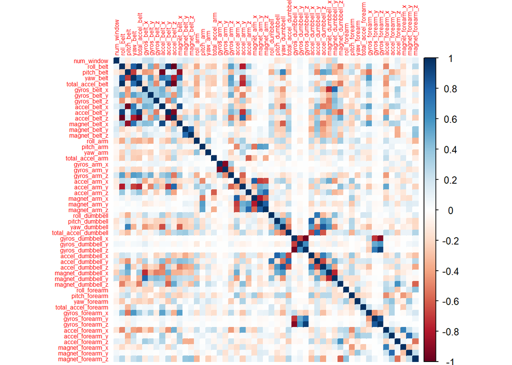

```r
corrplot(cor(train_df[, -length(names(train_df))]), method = "color", tl.cex = 0.5)
```

## Validation Set Generation

In this step we partition the training dataset and one of the partitions will be considered a **Validation Set** for the trained models. The split is made with 80% as training and 20% as validation data.

```r
set.seed(2403) # For reproducibile purpose
train_set <- createDataPartition(train_df$classe, p = 0.80, list = FALSE)
validation_df <- train_df[-train_set, ]
training_df <- train_df[train_set, ]
train_df <- training_df
```

# Decision Tree and Random Forest Model Fits

In this step we fit two models to the data, a decision tree and a random forest.

1. Decision Tree:

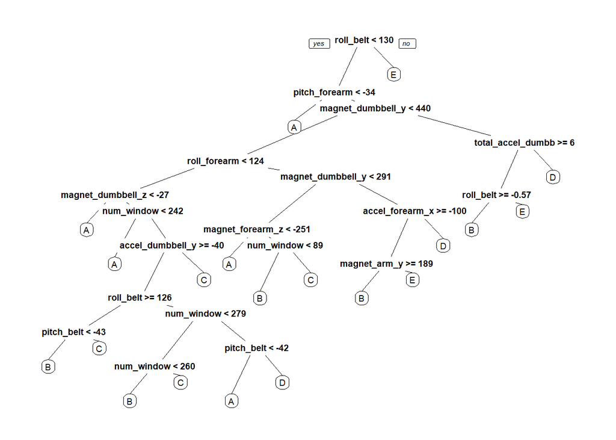

```r
decisionTree <- rpart(classe ~ ., data = train_df, method = "class")
prp(decisionTree)
```

A graphical representation of the decision tree is given below:

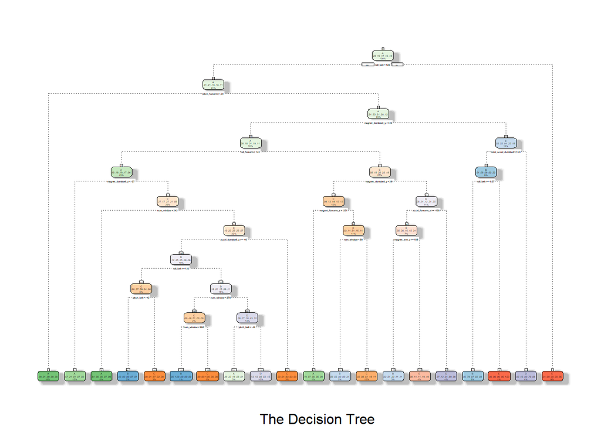

```r
fancyRpartPlot(decisionTree, sub = "The Decision Tree")
```

We now estimate the decision tree model performance on the **validation** set.

```r
prediction <- predict(decisionTree, validation_df, type = "class")
confusionMatrix(prediction, validation_df$classe)
```

```
## Confusion Matrix and Statistics
##
##           Reference
## Prediction   A   B   C   D   E
##          A 985 174  27  79  33
##          B  33 393  50  19  78
##          C  10  68 553  93  64
##          D  58  99  40 431  70
##          E  30  25  14  21 476
##
## Overall Statistics
##
##                Accuracy : 0.7234
##                  95% CI : (0.7091, 0.7374)
##     No Information Rate : 0.2845
##     P-Value [Acc > NIR] : < 2.2e-16
##
##                   Kappa : 0.6485
##
##  Mcnemar's Test P-Value : < 2.2e-16
##
## Statistics by Class:
##
##                      Class: A Class: B Class: C Class: D Class: E
## Sensitivity            0.8826   0.5178   0.8085   0.6703   0.6602
## Specificity            0.8885   0.9431   0.9274   0.9186   0.9719
## Pos Pred Value         0.7589   0.6859   0.7018   0.6175   0.8410
## Neg Pred Value         0.9501   0.8907   0.9582   0.9343   0.9270
## Prevalence             0.2845   0.1935   0.1744   0.1639   0.1838
## Detection Rate         0.2511   0.1002   0.1410   0.1099   0.1213
## Detection Prevalence   0.3309   0.1461   0.2009   0.1779   0.1443
## Balanced Accuracy      0.8856   0.7304   0.8680   0.7944   0.8160
```

```r
accuracy <- postResample(prediction, validation_df$classe)
ose <- 1 - as.numeric(confusionMatrix(validation_df$classe, prediction)$overall[1])
```

The Estimated Accuracy of the **Decision Tree** Model is 72.342595% and the Estimated Out-of-Sample Error is 27.657405%.

2. Random Forest:

The **Random Forest (RF)** algorithm selects critical input variables automatically. In additon the algorithm is also robust to outliers in general.  
We will use a **5-fold cross validation** scheme for the RF algorithm.

```r
rf_5_fold <- train(classe ~ ., data = train_df, method = "rf", trControl = trainControl(method = "cv", 5), ntree = 250)
rf_5_fold
```

```
## Random Forest
##
## 15699 samples
##    53 predictor
##     5 classes: 'A', 'B', 'C', 'D', 'E'
##
## No pre-processing
## Resampling: Cross-Validated (5 fold)
## Summary of sample sizes: 12560, 12560, 12559, 12559, 12558
## Resampling results across tuning parameters:
##
##   mtry  Accuracy   Kappa
##    2    0.9942032  0.9926665
##   27    0.9970059  0.9962127
##   53    0.9937575  0.9921035
##
## Accuracy was used to select the optimal model using the largest value.
## The final value used for the model was mtry = 27.
```

We now estimate the random forest model performance on the **validation** set.

```r
prediction <- predict(rf_5_fold, validation_df)
confusionMatrix(validation_df$classe, prediction)
```

```
## Confusion Matrix and Statistics
##
##           Reference
## Prediction    A    B    C    D    E
##          A 1115    1    0    0    0
##          B    1  756    1    1    0
##          C    0    0  684    0    0
##          D    0    0    0  642    1
##          E    0    2    0    0  719
##
## Overall Statistics
##
##                Accuracy : 0.9982
##                  95% CI : (0.9963, 0.9993)
##     No Information Rate : 0.2845
##     P-Value [Acc > NIR] : < 2.2e-16
##
##                   Kappa : 0.9977
##
##  Mcnemar's Test P-Value : NA
##
## Statistics by Class:
##
##                      Class: A Class: B Class: C Class: D Class: E
## Sensitivity            0.9991   0.9960   0.9985   0.9984   0.9986
## Specificity            0.9996   0.9991   1.0000   0.9997   0.9994
## Pos Pred Value         0.9991   0.9960   1.0000   0.9984   0.9972
## Neg Pred Value         0.9996   0.9991   0.9997   0.9997   0.9997
## Prevalence             0.2845   0.1935   0.1746   0.1639   0.1835
## Detection Rate         0.2842   0.1927   0.1744   0.1637   0.1833
## Detection Prevalence   0.2845   0.1935   0.1744   0.1639   0.1838
## Balanced Accuracy      0.9994   0.9975   0.9993   0.9991   0.9990
```

```r
accuracy <- postResample(prediction, validation_df$classe)
ose <- 1 - as.numeric(confusionMatrix(validation_df$classe, prediction)$overall[1])
```

The Estimated Accuracy of the Random Forest Model is 99.8215651% and the Estimated Out-of-Sample Error is 0.1784349%. As expected the Random Forest model has much better prediction accuracy.

Since the accuracy of the Random Forest model is much higher we apply RF to the test dataset for predicting the quality of the manner of the exercise performance. We will remove the **problem_id** input variable prior to applying the RF model

```r
test_set_prediction <- predict(rf_5_fold, test_df[, -length(names(test_df))])
```

Lastly we write the prediction results to file in the local filesystem which will be submitted as part of the requirements for the final project assignment.

```r
setwd("C:/Users/RDITLMR9/Desktop/ERDC Data Science/Johns Hopkins Univertisy/8. Practical Machine Learning/Project")
write_test_predictions_to_file = function(x){
  n = length(x)
  for(i in 1:n){
    filename = paste0("problem_id_",i,".txt")
    write.table(x[i],file=filename,quote=FALSE,row.names=FALSE,col.names=FALSE)
  }
}

write_test_predictions_to_file(test_set_prediction)
```